# Web Scraping and Data Exploration

Andy Chiv

2022-11-05

```r
library(tidyverse)
library(readr)
library(dplyr)
library(glue)
library(stringr)
library(rvest)
library(ggplot2)
library(forcats)
```

# Scrape the Location Counts

```r
# When Scraping the information from menuism.com, the process is the same, create a function is more efficient
scrape <- function(url){

  link <- read_html(url)
  data <- link %>%
    html_nodes('.col-sm-6') %>%
    html_nodes('a') %>%
    html_text() %>%
    as.data.frame()

  colnames(data) <- c('info')
  return (data)
}
```

```r
starbuck_url = "https://www.menuism.com/restaurant-locations/starbucks-coffee-39564"
starbuck_orig = scrape(starbuck_url)
starbuck_data <- starbuck_orig[-c(52:58), ] %>% as.data.frame()
colnames(starbuck_data) <- "info"

dunkin_url = "https://www.menuism.com/restaurant-locations/dunkin-donuts-181624/us"
dunkin_orin = scrape(dunkin_url)
dunkin_data = dunkin_orin

peet_url = "https://www.menuism.com/restaurant-locations/peets-coffee-tea-84051"
peet_orig = scrape(peet_url)
peet_data = peet_orig[-c(10), ] %>% as.data.frame()
colnames(peet_data) <- "info"

tim_url = "https://www.menuism.com/restaurant-locations/tim-hortons-190025"
tim_orig = scrape(tim_url)
tim_data = tim_orig[-c(17:23), ] %>% as.data.frame()
colnames(tim_data) <- "info"

panera_url = "https://www.menuism.com/restaurant-locations/panera-bread-4258"
panera_orig = scrape(panera_url)
panera_data = panera_orig[-c(1, 47), ] %>% as.data.frame()
colnames(panera_data) <- "info"

caribou_url = "https://www.menuism.com/restaurant-locations/caribou-coffee-164861"
caribou_orig = scrape(caribou_url)
caribou_data = caribou_orig


au_url = "https://www.menuism.com/restaurant-locations/au-bon-pain-69342"
au_orig = scrape(au_url)
au_data = au_orig

leaf_url = "https://www.menuism.com/restaurant-locations/the-coffee-bean-tea-leaf-165988"
leaf_orig = scrape(leaf_url)
leaf_data = leaf_orig

mc_url = "https://www.menuism.com/restaurant-locations/mcdonalds-21019"
mc_orig = scrape(mc_url)
mc_data = mc_orig[-c(1,2, 52:94), ] %>% as.data.frame()
colnames(mc_data) <- "info"
```

### This function stateabb() takes a state name (assume it’s spelled correctly) and converts it to its state abbreviation.

```r
stateabb <- function(one_state){

  # Manually fix for state Virginia
  if (one_state == "Virginia"){
    return ("VA")}
  if (one_state == "District of Columbia"){
    return ("DC")
  }
  # Locate the index of the state
  state_index <- grep(one_state, state.name)

  # Access the state abbreviation with the index
  state_result <- state.abb[state_index]

  return (state_result)
}
```

### Parse, merge and tidy your data so that you have a row for each state and two columns: state abbrevation, location count.

```r
extract_state <- function(string, store){
  pattern <- glue('.+?(?= ','{store}',')')
  result <- str_extract(string, pattern)
  return (result)
}


extract_count <- function(string){
  # Extract Count
  count = str_extract_all(string, "[0-9]") %>%
  unlist() %>% paste0(collapse = '')
  return (as.integer(count))
}

# Create a function to combine both state and count
cleanup <- function(data, store){
  state = map_chr(data, function(x) extract_state(x, store))
  count = map_int(data, function(x) extract_count(x))
  # Combine state and count into a dataframe
  final_data = data.frame(state, count)
  return (final_data)
}
```

### Clean Dataset for each coffee shop

```r
au_clean <- cleanup(au_data$info, store ="Au Bon Pain")
company <- rep("Au Bon Pain", nrow(au_clean))
au_clean <- data.frame(company, au_clean)

caribou_clean <- cleanup(caribou_data$info, store ="Caribou")
company <- rep("Caribou Coffee", nrow(caribou_clean))
caribou_clean <- data.frame(company, caribou_clean)

dunkin_clean <- cleanup(dunkin_data$info, store = "Dunkin")
company <- rep("Dunkin’ Donuts", nrow(dunkin_clean))
dunkin_clean <- data.frame(company, dunkin_clean)

leaf_clean <- cleanup(leaf_data$info, store = "The Coffee Bean")
company <- rep("The Coffee Bean & Tea Leaf", nrow(leaf_clean))
leaf_clean <- data.frame(company, leaf_clean)

mc_clean <- cleanup(mc_data$info, store = "McDonald's")
company <- rep("McDonald", nrow(mc_clean))
mc_clean <- data.frame(company, mc_clean)

panera_clean <- cleanup(panera_data$info, store="Panera")
company <- rep("Panera Bread", nrow(panera_clean))
panera_clean <- data.frame(company, panera_clean)

peet_clean <- cleanup(peet_data$info, store="Peet")
company <- rep("Peet’s Coffee & Tea", nrow(peet_clean))
peet_clean <- data.frame(company, peet_clean)

starbuck_clean <- cleanup(starbuck_data$info, store="Starbucks")
company <- rep("Starbucks", nrow(starbuck_clean))
starbuck_clean <- data.frame(company, starbuck_clean)

tim_clean <- cleanup(tim_data$info, store = "Tim")
company <- rep("Tim Horton’s", nrow(tim_clean))
tim_clean <- data.frame(company, tim_clean)
```

```r
dataset <- rbind(au_clean, caribou_clean, dunkin_clean, leaf_clean, mc_clean,
                 panera_clean, peet_clean, starbuck_clean, tim_clean)


# Update State Abbreviation
state_abbreviation <- sapply(dataset$state,stateabb) %>% unname()

# Final Coffee Data Set
dataset$state <- state_abbreviation
head(dataset)
```

```
##       company state count
## 1 Au Bon Pain    CT     8
## 2 Au Bon Pain    DC    21
## 3 Au Bon Pain    FL    23
## 4 Au Bon Pain    GA     3
## 5 Au Bon Pain    IL    32
## 6 Au Bon Pain    IN     8
```

# Scrape State Population as Supplemental Data

### Scrape the state names and populations from this wikipedia page. Convert the state names to abbreviations and merge these data with your coffee dataset.

```r
wiki_url <- "https://simple.wikipedia.org/wiki/List_of_U.S._states_by_population"
wiki_html <- read_html(wiki_url)
wiki_orig <- wiki_html %>% html_nodes('table') %>% html_table()
wiki_data <- wiki_orig[[1]]
```

```r
# Only need state and population
wiki <- wiki_data %>% select(c(3,4))

# Rename the colume
colnames(wiki) <- c("state", "population")

# Remove non state
wiki <- wiki %>% filter(state %in% state.name) %>% as.data.frame()

# Abbreviate the states and update wiki
state_abbreviation <- sapply(wiki$state, stateabb) %>% unname()
wiki$state <- state_abbreviation
```

```r
# Remove the comma in Population and Convert it into numeric value
remove_punc <- function(str){
  my_str <- str_remove_all(str, '\\,')
  return (as.integer(my_str))
}

# Covert populaton to numeric
population <- sapply(wiki$population, remove_punc) %>% unname()
wiki$population <- population

# Add District of Columnia in wiki dataframe
DC <- data.frame(state='DC', population = 701974)
wiki <- rbind(wiki, DC)
```

```r
#dataset1 <- merge(dataset, wiki, by='state', all.x = TRUE)
dataset1 <- dplyr::left_join(dataset, wiki, by='state')
head(dataset1)
```

```
##       company state count population
## 1 Au Bon Pain    CT     8    3565287
## 2 Au Bon Pain    DC    21     701974
## 3 Au Bon Pain    FL    23   19453561
## 4 Au Bon Pain    GA     3   10617423
## 5 Au Bon Pain    IL    32   12801989
## 6 Au Bon Pain    IN     8    6732219
```

### Manually insert revenue value for each store

```r
# Using Revenue (2021) in million dollars as a financial metric
starbuck = 24610
dunkin = 1370
peet = 983
tom = 6526
panera = 5763
caribou = 262
au = 41
leaf = 500
mc = 23220

company = c("Starbucks", "Dunkin’ Donuts","Peet’s Coffee & Tea",
            "Tim Horton’s", "Panera Bread", "Caribou Coffee", "Au Bon Pain",
            "The Coffee Bean & Tea Leaf", "McDonald")
revenue <- c(starbuck, dunkin, peet, tom, panera, caribou, au, leaf, mc)

(company_revenue <- data.frame(company, revenue))
```

```
##                      company revenue
## 1                  Starbucks   24610
## 2             Dunkin’ Donuts    1370
## 3        Peet’s Coffee & Tea     983
## 4               Tim Horton’s    6526
## 5               Panera Bread    5763
## 6             Caribou Coffee     262
## 7                Au Bon Pain      41
## 8 The Coffee Bean & Tea Leaf     500
## 9                   McDonald   23220
```

```r
dataset2 <- left_join(dataset1, company_revenue, by='company')
head(dataset2)
```

```
##       company state count population revenue
## 1 Au Bon Pain    CT     8    3565287      41
## 2 Au Bon Pain    DC    21     701974      41
## 3 Au Bon Pain    FL    23   19453561      41
## 4 Au Bon Pain    GA     3   10617423      41
## 5 Au Bon Pain    IL    32   12801989      41
## 6 Au Bon Pain    IN     8    6732219      41
```

### Create a region variable: Northeast, Midwest, South, West.

```r
state_reg <- function(state_abbre){

  west <- c('CA', 'WA', 'OR', 'ID', 'MT', 'WY', 'NV', 'UT', 'CO',
            'AZ', 'NM', 'AK', 'HI')
  midwest <- c('ND', 'SD', 'NE', 'KS', 'MN', 'IA',
               'MO', 'WI', 'IL', 'IN', 'MI', 'OH')
  south <- c('TX', 'OK', 'AR', 'LA', 'MS', 'TN', 'KY', 'WV',
             'MD', 'DE', 'DC', 'VA', 'NC', 'SC', 'GA', 'FL', 'AL')
  northeast <- c('PA', 'NJ', 'NY', 'MA', 'CT', 'RI', 'VT', 'NH', 'ME', 'DC')

  if (state_abbre %in% west ){
    return ('West')
  } else if (state_abbre %in% midwest){
    return ('Midwest')
  } else if (state_abbre %in% south){
    return ('South')
  } else{ # if (state_abbre %in% northeast){
    return ('Northeast')
  }
}
```

```r
region <- sapply(dataset2$state, state_reg) %>% unlist() %>% unname()
dataset2$region <- region
head(dataset2)
```

```
##       company state count population revenue    region
## 1 Au Bon Pain    CT     8    3565287      41 Northeast
## 2 Au Bon Pain    DC    21     701974      41     South
## 3 Au Bon Pain    FL    23   19453561      41     South
## 4 Au Bon Pain    GA     3   10617423      41     South
## 5 Au Bon Pain    IL    32   12801989      41   Midwest
## 6 Au Bon Pain    IN     8    6732219      41   Midwest
```

# What kind of insights or trends can we get from this dataset?

#### A. Are some of these chains more prevalent in certain states than others? However in certain regions?

```r
dataset2 %>% select(company, state, count) %>%
  arrange(desc(count)) %>%
  top_n(10)
```

```
##           company state count
## 1       Starbucks    CA  2362
## 2        McDonald    CA  1623
## 3        McDonald    TX  1303
## 4        McDonald    FL  1142
## 5  Dunkin’ Donuts    MA  1101
## 6  Dunkin’ Donuts    NY  1022
## 7        McDonald    OH   843
## 8        McDonald    NY   811
## 9        McDonald    IL   791
## 10      Starbucks    TX   720
```

Starbucks, Mcdonald and Dunkin’s Donuts dominate in the certain states including California, Texas, Florida, and York.

```r
dataset2 %>% select(company, region, count) %>%
  arrange(desc(count)) %>%
  top_n(10)
```

```
##           company    region count
## 1       Starbucks      West  2362
## 2        McDonald      West  1623
## 3        McDonald     South  1303
## 4        McDonald     South  1142
## 5  Dunkin’ Donuts Northeast  1101
## 6  Dunkin’ Donuts Northeast  1022
## 7        McDonald   Midwest   843
## 8        McDonald Northeast   811
## 9        McDonald   Midwest   791
## 10      Starbucks     South   720
```

Some companies including Starbuck, Mcdonald and Dunkin’s Donuts have the most locations in all regions.

#### B. Does the distribution of each chain’s stores match population distribution by state?

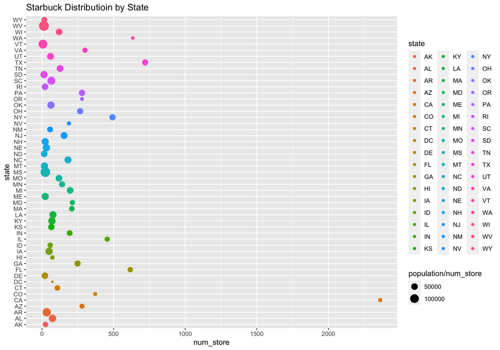

```r
dataset2 %>% select(-c(region)) %>%
  group_by(state, company) %>%
  summarise(num_store = sum(count), population = mean(population), revenue = mean(revenue)) %>%
  filter(company == 'Starbucks') %>%
  ggplot(aes(y=state, x=num_store, color=state, size = population/num_store)) +
  geom_point() +
  labs(title = "Starbuck Distributioin by State")
```

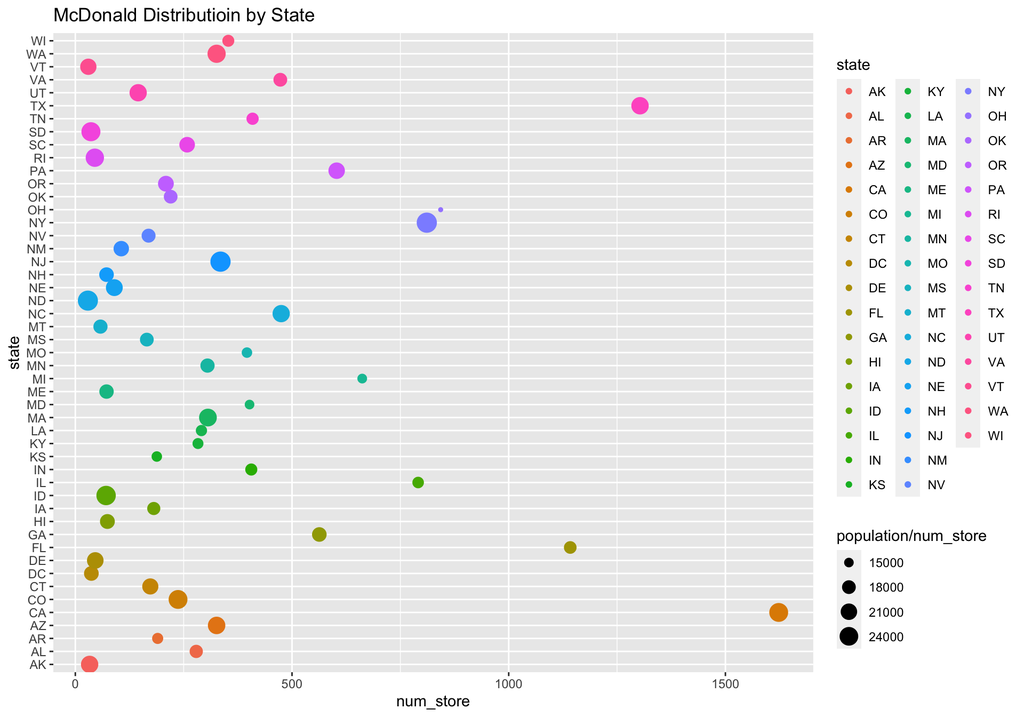

```r
dataset2 %>% select(-c(region)) %>%
  group_by(state, company) %>%
  summarise(num_store = sum(count), population = mean(population), revenue = mean(revenue)) %>%
  filter(company == 'McDonald') %>%
  ggplot(aes(y=state, x=num_store, color=state, size = population/num_store)) +
  geom_point() +
  labs(title = "McDonald Distributioin by State")
```

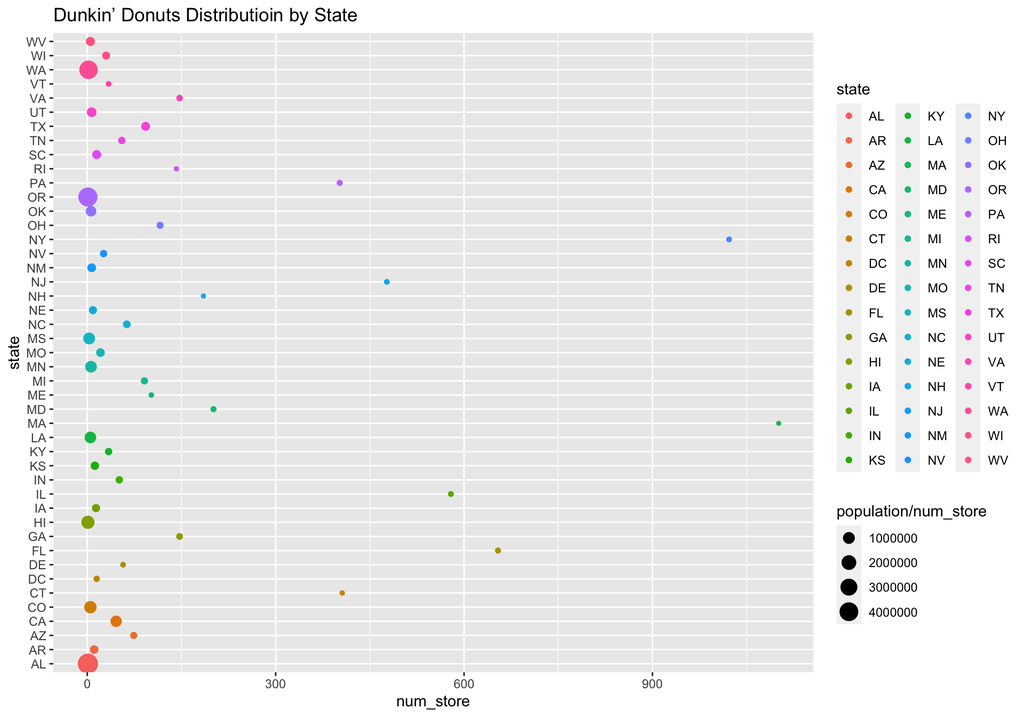

```r
dataset2 %>% select(-c(region)) %>%
  group_by(state, company) %>%
  summarise(num_store = sum(count), population = mean(population), revenue = mean(revenue)) %>%
  filter(company == 'Dunkin’ Donuts') %>%
  ggplot(aes(y=state, x=num_store, color=state, size = population/num_store)) +
  geom_point() +
  labs(title = "Dunkin’ Donuts Distributioin by State")
```

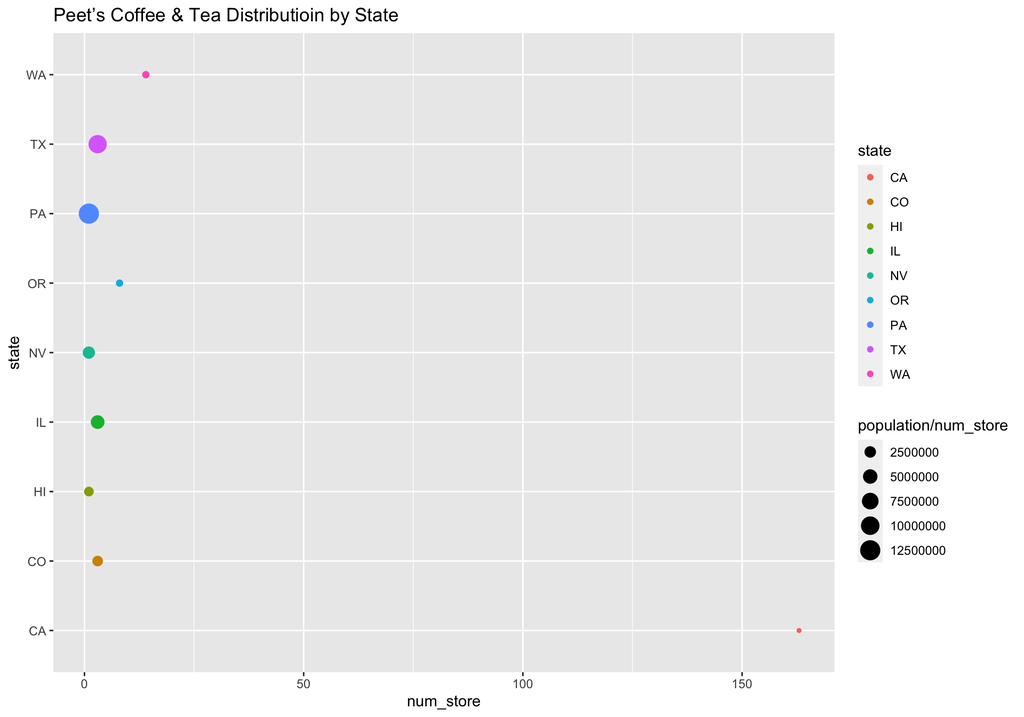

```r
dataset2 %>% select(-c(region)) %>%
  group_by(state, company) %>%
  summarise(num_store = sum(count), population = mean(population), revenue = mean(revenue)) %>%
  filter(company == 'Peet’s Coffee & Tea') %>%
  ggplot(aes(y=state, x=num_store, color=state, size = population/num_store)) +
  geom_point() +
  labs(title = "Peet’s Coffee & Tea Distributioin by State")
```

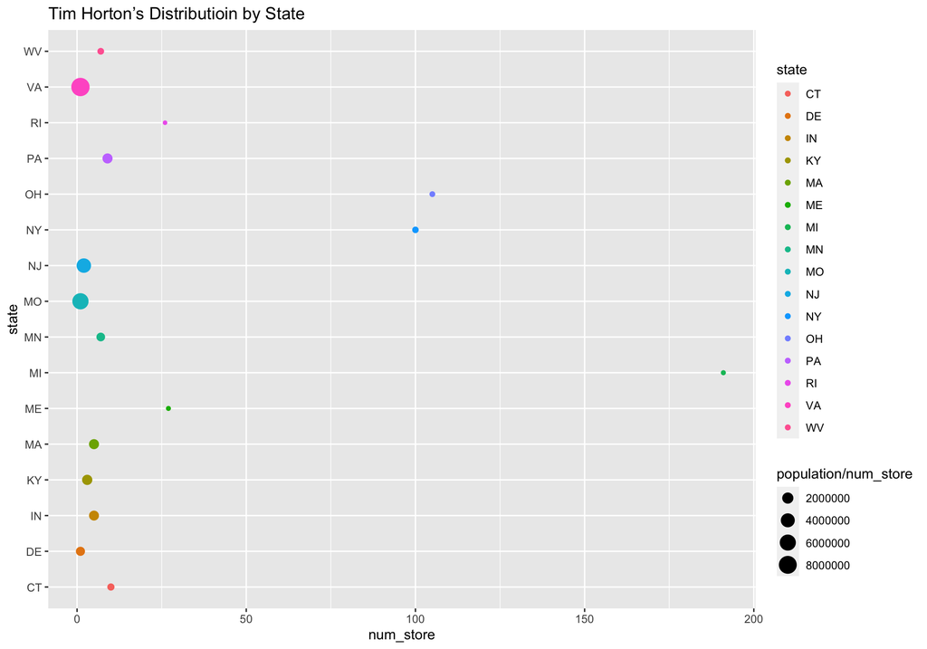

```r
dataset2 %>% select(-c(region)) %>%
  group_by(state, company) %>%
  summarise(num_store = sum(count), population = mean(population), revenue = mean(revenue)) %>%
  filter(company == 'Tim Horton’s') %>%
  ggplot(aes(y=state, x=num_store, color=state, size = population/num_store)) +
  geom_point() +
  labs(title = "Tim Horton’s Distributioin by State")
```

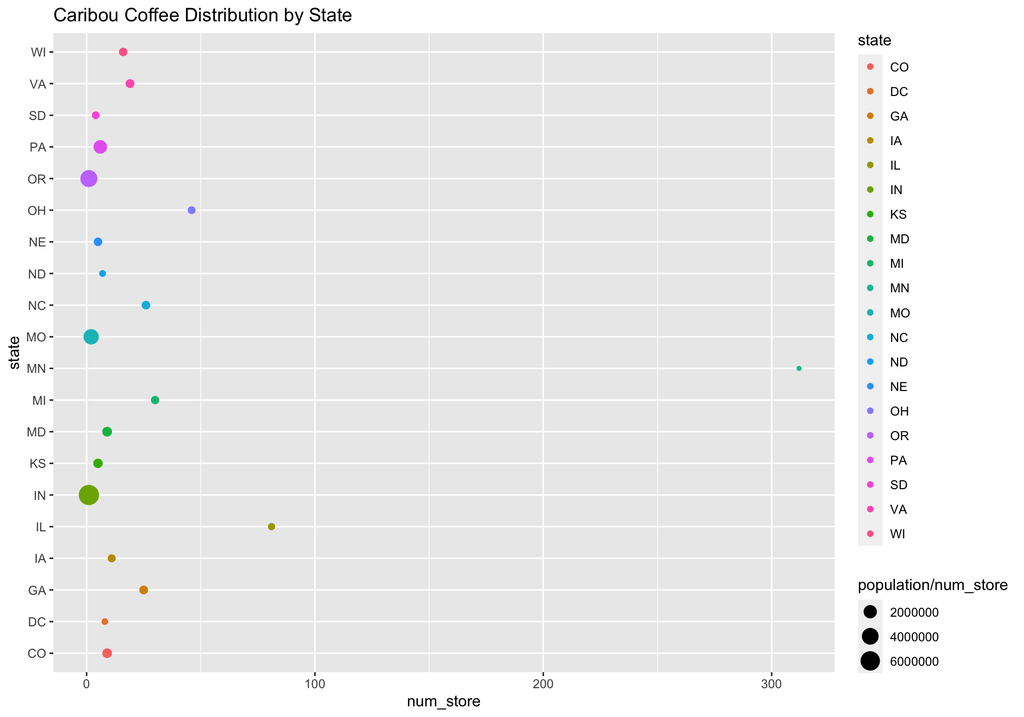

```r
dataset2 %>% select(-c(region)) %>%
  group_by(state, company) %>%
  summarise(num_store = sum(count), population = mean(population), revenue = mean(revenue)) %>%
  filter(company == 'Caribou Coffee') %>%
  ggplot(aes(y=state, x=num_store, color=state, size = population/num_store)) +
  geom_point() +
  labs(title = "Caribou Coffee Distribution by State")
```

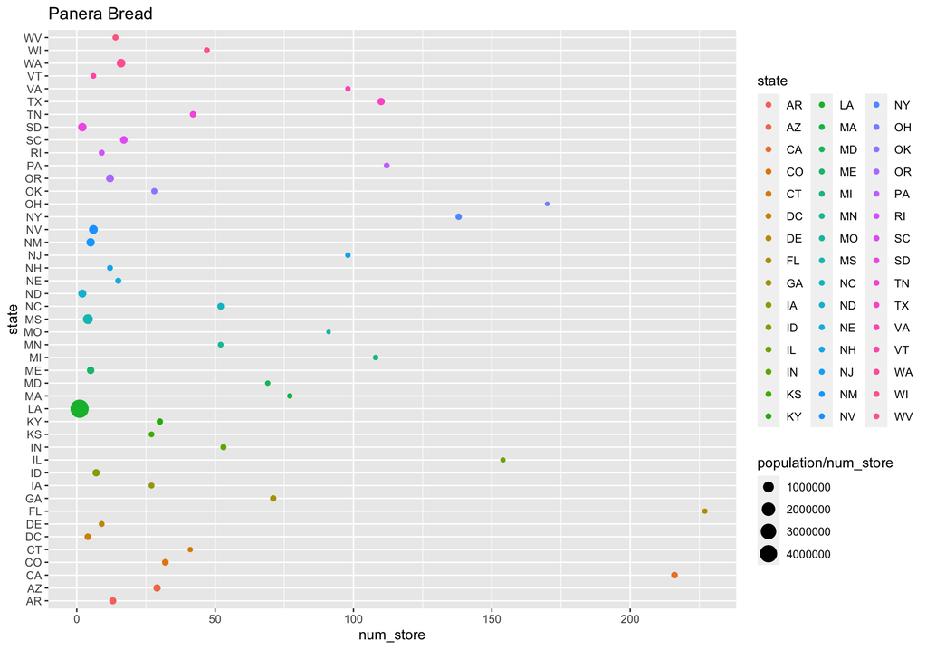

```r
dataset2 %>% select(-c(region)) %>%
  group_by(state, company) %>%
  summarise(num_store = sum(count), population = mean(population), revenue = mean(revenue)) %>%
  filter(company == 'Panera Bread') %>%
  ggplot(aes(y=state, x=num_store, color=state, size = population/num_store)) +
  geom_point() +
  labs(title = "Panera Bread")
```

All the visuals above indicate that some chain restaurants do not have an equal distribution of their locations in comparison to the state population. That is indicated by the size of the circles.

#### C. Do the financial data match what you’d expect based on the number and locations of the stores? Why or why not?

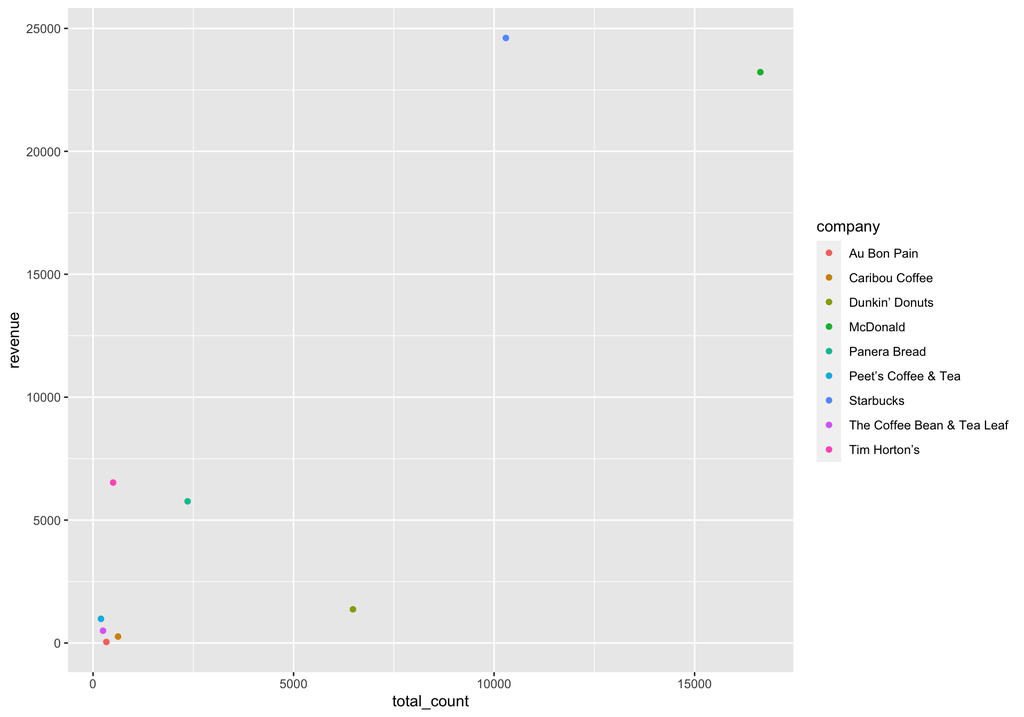

```r
dataset2 %>%
  select(company, count, revenue) %>%
  group_by(company) %>%
  summarise(total_count = sum(count), revenue = mean(revenue)) %>%

  ggplot(aes(x= total_count, y= revenue, color = company)) +
  geom_point()
```

1. Question D: Rank the total number of store by each restaurant

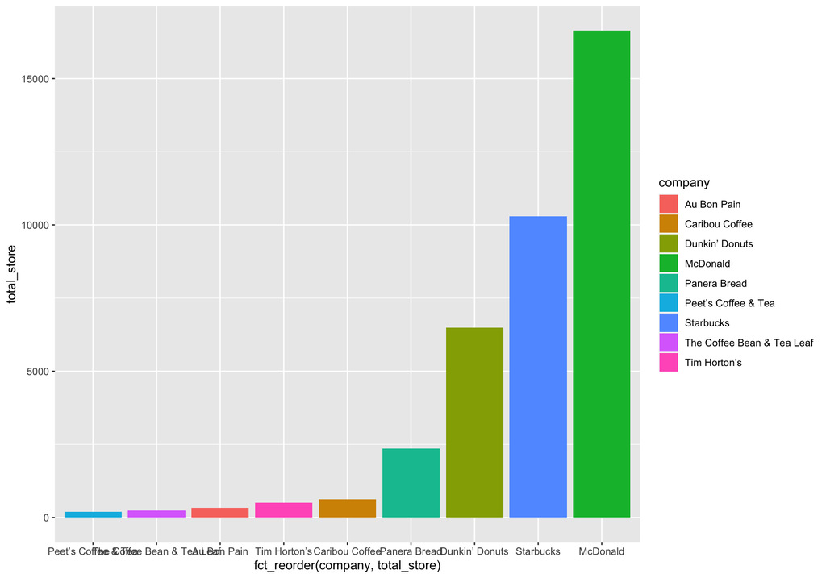

```r
dataset2 %>% select(company, count) %>%
  group_by(company) %>%
  summarize(total_store = sum(count)) %>%
  ggplot(aes(x=fct_reorder(company, total_store), y=total_store, fill = company)) +
  geom_col()
```

3 top coffee company with the most locations in the US are McDonalad, Starbuck and Dunkin Donuts

1. Question E: Rank the total number of store by state

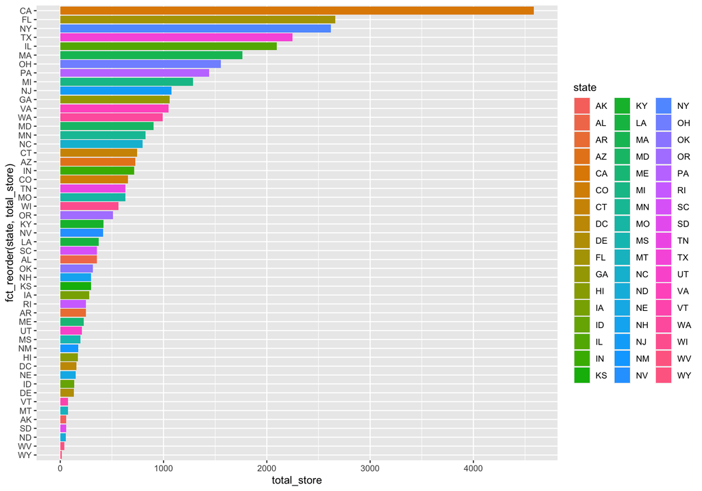

```r
dataset2 %>% select(state, count) %>%
  group_by(state) %>%
  summarize(total_store = sum(count)) %>%
  ggplot(aes(y=fct_reorder(state, total_store), x=total_store, fill = state)) +
  geom_col()
```

As expected, top 3 states with the most coffee shops are California, New York and Florida.